# Sorting by fractal dimension

Steve Simon

February 22, 2018

WARNING!! The geom_sf function in ggplot2 is experimental and not yet part of the regular package (at least not at the time I wrote this, February 2018). You have to install a special version of ggplot2 using the RTools package. For details, go to

https://dcl-2017-01.github.io/curriculum/notes/spatial-vis.html

and note the installation instructions at the very top of the page.

```r
library(ggmap)
```

```r
library(ggplot2)
library(geosphere)
library(magrittr)
library(maptools)
library(rvest)
library(sf)
library(tidyverse)
library(viridis)
```

The fractal dimension was estimated by box counting and the results stored in csv files in the results subdirectory.

```r
pn <- "~/mapping-shapefiles/results"
pa <- "*.csv"
fn <- list.files(pn, pa)
n <- length(fn)
fd <- data.frame(district=rep(-1, n), fractal_dimension=rep(-1, n))
for (i in 1:n) {
  fr <- read.csv(paste(pn, fn[i], sep="/"), header=TRUE)
  fd$district[i] <- fr$d[1]
  fd$fractal_dimension[i] <- coef(lm(log2(y)~x, data=fr))[2]
}
fd$district <- paste0(ifelse(fd$district <= 999, "0", ""), fd$district)
fd %<>% arrange(desc(fractal_dimension))
head(fd, 20)
```

```
##    district fractal_dimension
## 1      4833          1.263270
## 2      3903          1.258193
## 3      2402          1.254555
## 4      4213          1.246989
## 5      4207          1.241069
## 6      2403          1.239529
## 7      4206          1.232833
## 8      2206          1.229354
## 9      3911          1.211772
## 10     4835          1.209529
## 11     2408          1.208348
## 12     2202          1.207463
## 13     3607          1.206640
## 14     2507          1.205265
## 15     1205          1.203512
## 16     4802          1.200170
## 17     0631          1.199933
## 18     4834          1.197057
## 19     5111          1.197038
## 20     4818          1.196633
```

I have gotten some help from

Roger Bivand. Combining Spatial Data vignette. March 25, 2017. Available at https://cran.r-project.org/web/packages/maptools/vignettes/combine_maptools.pdf

Matt Strimas-Mackey. Tidy Spatial Data in R, Using dplyr, tidyr, and ggplot2 with sf. March 9, 2017. Available at http://strimas.com/r/tidy-sf/

Edzer Pebesma. Spatial Data in R: New Directions. July 4, 2017. Available at https://edzer.github.io/UseR2017/

Simple Features for R. Available at https://cran.r-project.org/web/packages/sf/vignettes/sf1.html

Manipulating Simple Feature Geometries. Available at https://cran.r-project.org/web/packages/sf/vignettes/sf3.html

Melanie Frazier. Overview of Coordinate Reference Systems (CRS) in R.

The file used in this example, cb_2016_us_cd115_500k.shp, was downloaded from https://www.census.gov/geo/maps-data/data/cbf/cbf_cds.html.

The 500K means that the scale is 1:500,000 which is the highest resolution available.

```r
path_name <- "~/mapping-shapefiles/shp"
file_name <- "cb_2016_us_cd115_500k.shp"
path_name                              %>%
  paste(file_name, sep="/")            %>%
  st_read(stringsAsFactors=FALSE)      -> all_districts
names(all_districts)
```

```
## [1] "STATEFP"  "CD115FP"  "AFFGEOID" "GEOID"    "LSAD"     "CDSESSN"
## [7] "ALAND"    "AWATER"   "geometry"
```

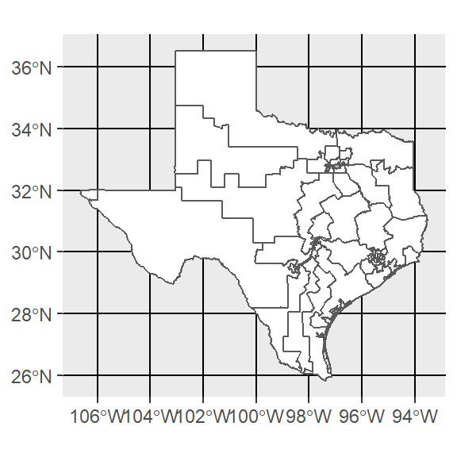

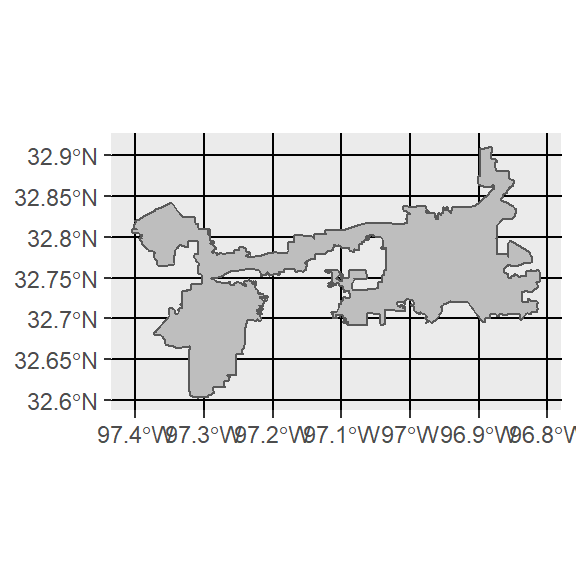

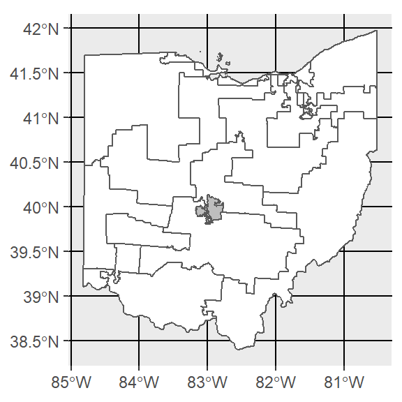

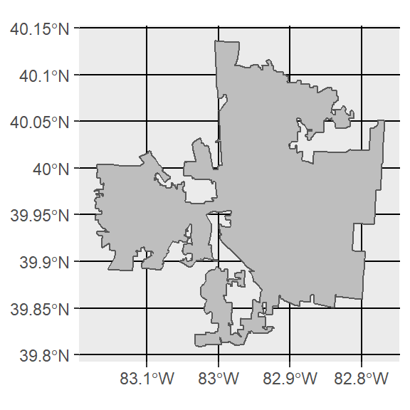

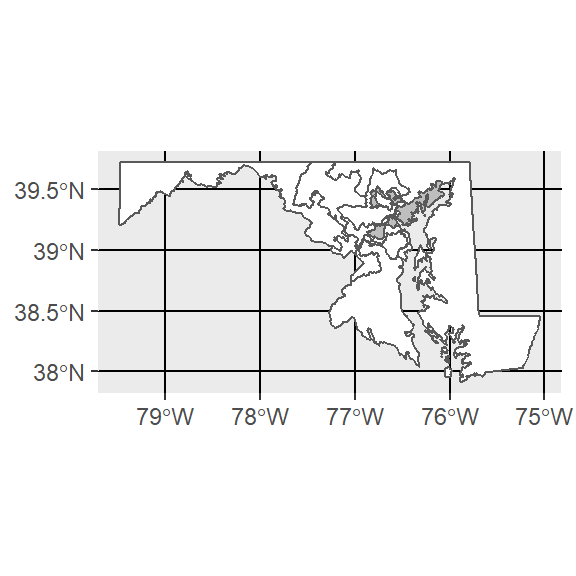

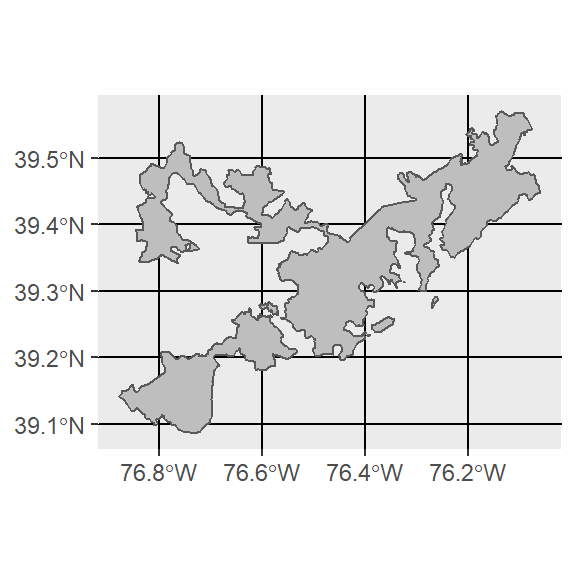

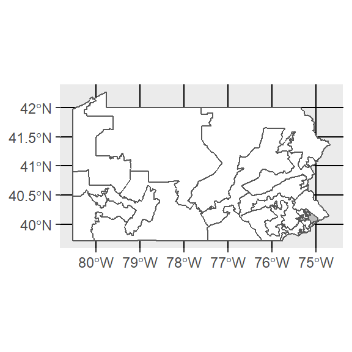

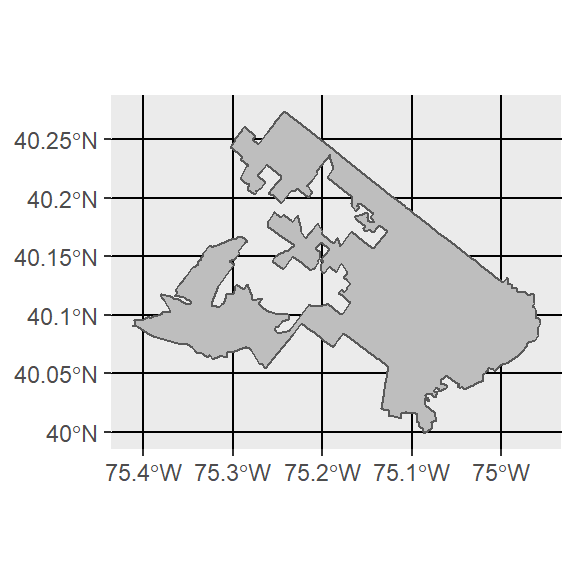

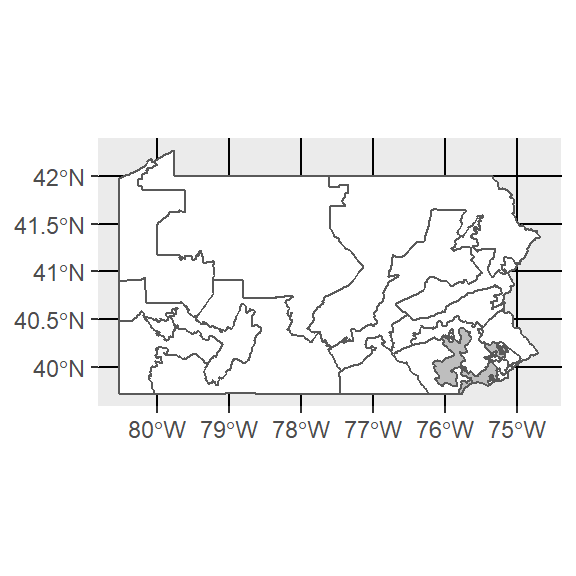

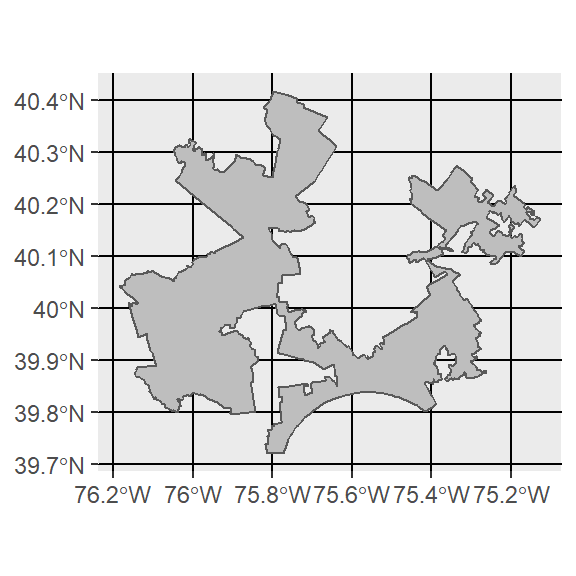

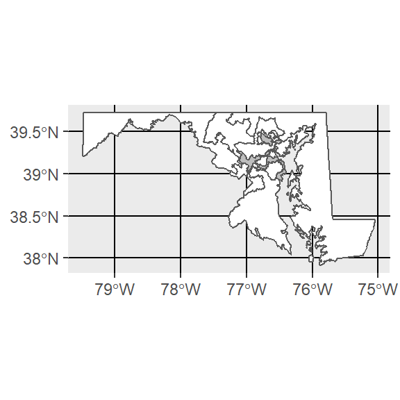

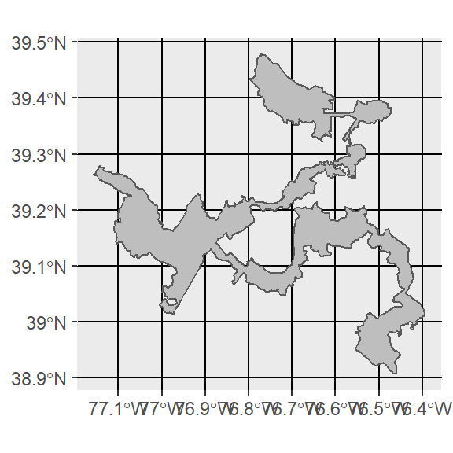

[28 more figures not shown]

```r
highlight_district <- function(district_number) {
  state_fips_code <- substr(district_number, 1, 2)
  district_string <- as.character(district_number)
  all_districts                          %>%
    mutate(fill_color=
      ifelse(GEOID==district_number,
        district_string, "others"))      -> single_district
  single_district                        %>%
    filter(STATEFP==state_fips_code)     %>%
    ggplot()                              +
    geom_sf(aes(fill=fill_color))         +
    scale_fill_manual(
      values=c("gray", "white"))          +
    theme(legend.position="none")
}
isolate_district <- function(district_number) {
  district_string <- as.character(district_number)
  all_districts                          %>%
    filter(GEOID==district_string)       %>%
    ggplot()                              +
    geom_sf(fill="gray")
}
for (i in 1:20) {
  fd$district[i]                         %>%
    highlight_district                   %>%
    plot
  fd$district[i]                         %>%
    isolate_district                     %>%
    plot
}
```

```r
save.image("~/mapping-shapefiles/data/fractal.RData")
```